# Линейная регрессия

## Мы рассмотрим

- Базовые идеи корреляционного анализа
- Проблему двух статистических подходов: "Тестирование гипотез vs. построение моделей"
- Разнообразие статистических моделей
- Основы регрессионного анализа

## Вы сможете

- Оценить взаимосвязь между измеренными величинами
- Объяснить что такое линейная модель
- Формализовать запись модели в виде уравнения
- Подобрать модель линейной регрессии
- Проверить состоятельность модели при помощи t-критерия или F-критерия
- Оценить предсказательную силу модели

## Знакомимся с даными

## Зависит ли уровень интеллекта от размера головного мозга?

- Было исследовано 20 девушек и 20 молодых людей
- У каждого индивида определяли биометрические параметры: вес, рост, размер головного мозга (количество пикселей на изображении ЯМР сканера)
- Интеллект был протестирован с помощью IQ тестов

Пример взят из работы: Willerman, L., Schultz, R., Rutledge, J. N., and Bigler, E. (1991), "In Vivo Brain Size and Intelligence," Intelligence, 15, 223-228.  
Данные представлены в библиотеке *"The Data and Story Library"* http://lib.stat.cmu.edu/DASL/

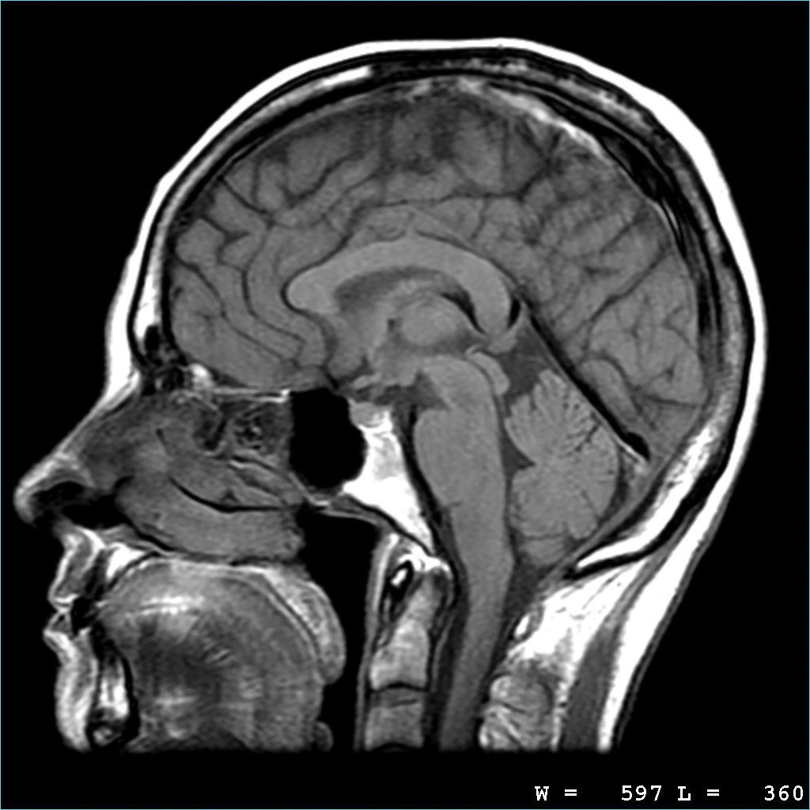

## Посмотрим на датасет

```r
brain <- read.csv("data/IQ_brain.csv", header = TRUE)
head(brain)
```

```
##   Gender FSIQ VIQ PIQ Weight Height MRINACount
## 1 Female  133 132 124    118   64.5     816932
## 2   Male  140 150 124     NA   72.5    1001121
## 3   Male  139 123 150    143   73.3    1038437
## 4   Male  133 129 128    172   68.8     965353
## 5 Female  137 132 134    147   65.0     951545
## 6 Female   99  90 110    146   69.0     928799
```

## Основы корреляционного анализа

## Вспомним: *Сила и направление связи между величинами*

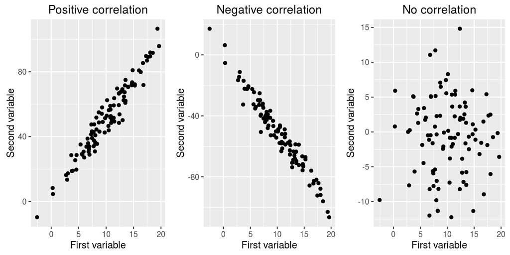

## Коэффициенты корреляции и условия их применимости

| Коэффициент | Фукция | Особенности примененения |
| --- | --- | --- |
| Коэф. Пирсона | `cor(x,y,method="pearson")` | Оценивает связь двух нормально распределенных величин. Выявляет только лиейную составляющую взамосвязи. |
| Ранговые коэффициенты (коэф. Спирмена, Кэндалла) | `cor(x,y,method="spirman")` `cor(x,y,method="kendall")` | Не зависят от формы распределения. Могут оценивать связь для любых монотонных зависимостей. |

## Оценка достоверности коэффициентов корреляции

- Коэффициент корреляции - это статистика, значение которой описывает степень взаимосвязи двух сопряженных переменных. Следовательно применима логика статистического критерия.
- Нулевая гипотеза \(H_0: r=0\)
- Бывают двусторонние \(H_a: r\ne 0\) и односторонние критерии \(H_a: r>0\) или \(H_a: r<0\)
- Ошибка коэффициента Пирсона: \(SE_r=\sqrt{\frac{1-r^2}{n-2}}\)
- Стандартизованная величина \(t=\frac{r}{SE_r}\) подчиняется распределению Стьюдента с парметром \(df = n-2\)
- Для ранговых коэффициентов существует проблема "совпадающих рангов" (tied ranks), что приводит к приблизительной оценке \(r\) и приблизительной оценке уровня значимости.
- Достоверность коэффициента кореляции можно оценить пермутационным методом

## Задание

- Определите силу и направление связи между всеми парами исследованных признаков
- Постройте точечную диаграмму, отражающую взаимосвязь между результатами IQ-теста (PIQ) и размером головного мозга (MRINACount)
- Оцените достоверность значения коэффициента корреляции Пирсона между этими двумя перменными

*Hint 1*: Обратите внимание на то, что в датафрейме есть пропущенные значения. Изучите, как работают c `NA` функуции, вычисляющие коэффициенты корреляции.

*Hint 2* Для построения точечной диаграммы вам понадобится `geom_point()`

## Решение

```r
cor(brain[, 2:6], use = "pairwise.complete.obs")
```

```
##           FSIQ     VIQ      PIQ   Weight  Height
## FSIQ    1.0000  0.9466  0.93413 -0.05148 -0.0860
## VIQ     0.9466  1.0000  0.77814 -0.07609 -0.0711
## PIQ     0.9341  0.7781  1.00000  0.00251 -0.0767
## Weight -0.0515 -0.0761  0.00251  1.00000  0.6996
## Height -0.0860 -0.0711 -0.07672  0.69961  1.0000
```

```r
cor.test(brain$PIQ, brain$MRINACount, method = "pearson", alternative = "two.sided")
```

[output not shown]

## Решение

```r
pl_brain <- ggplot(brain, aes(x = MRINACount, y = PIQ)) + geom_point() +
    xlab("Brain size") + ylab("IQ test")
```

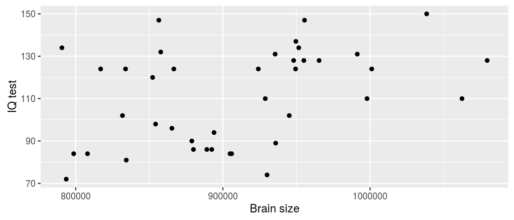

```r
pl_brain
```

## Два подхода к исследованию: Тестирование гипотезы VS Построение модели

- Проведя корреляционный анализ, мы лишь ответили на вопрос "Существет ли достоверная связь между величинами?"
- Сможем ли мы, используя это знание, *предсказть* значения одной величины, исходя из знаний другой?

## Тестирование гипотезы VS построение модели

- Простейший пример
- Между путем, пройденным автомобилем, и временем, проведенным в движении, несомнено есть связь. Хватает ли нам этого знания?
- Для расчета величины пути в зависимости от времени необходимо построить модель: \(S=Vt\), где \(S\) - зависимая величина, \(t\) - независимая переменная, \(V\) - параметр модели.
- Зная параметр модели (скорость) и значение независимой переменной (время), мы можем рассчитать (*cмоделировать*) величину пройденного пути

## Какие бывают модели?

## Линейные и нелинейные модели

Линейные модели \[y = b_0 + b_1x\]  
\[y = b_0 + b_1x_1 + b_2x_2\] Нелинейные модели \[y = b_0 + b_1^x\]  
\[y = b_0^{b_1x_1+b_2x_2}\]

## Простые и многокомпонентные (множественные) модели

- Простая модель \[y = b_0 + b_1x\]
- Множественная модель \[y = b_0 + b_1x_1 + b_2x_2 + b_3x_3 + ... + b_nx_n\]

## Детерминистские и стохастические модели

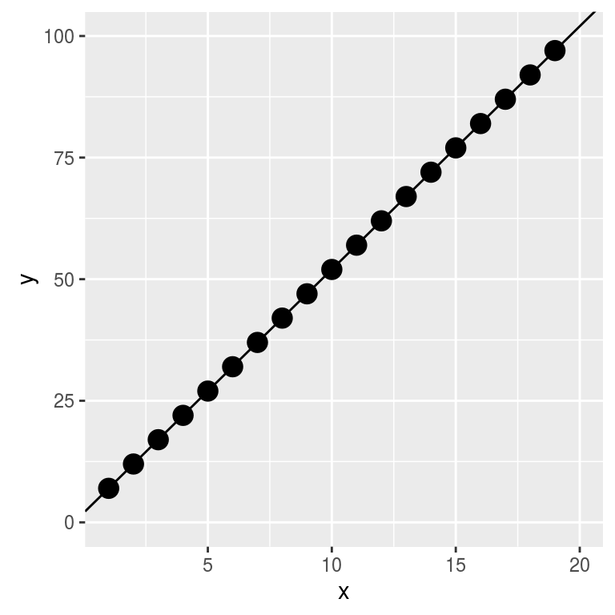

Модель: \(у_i = 2 + 5x_i\)  
Два парметра: угловой коэффициент (slope) \(b_1=5\); свободный член (intercept) \(b_0=2\) Чему равен \(y\) при \(x=10\)?

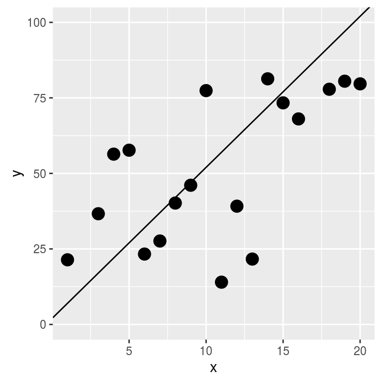

Модель: \(у = 2 + 5x + \epsilon\)  
Появляется дополнительный член \(\epsilon_i\) Он вводит в модель влияние неучтенных моделью факторов. Обычно считают, что \(\epsilon \in N(0, \sigma^2)\)

## Модели с дискретными предикторами

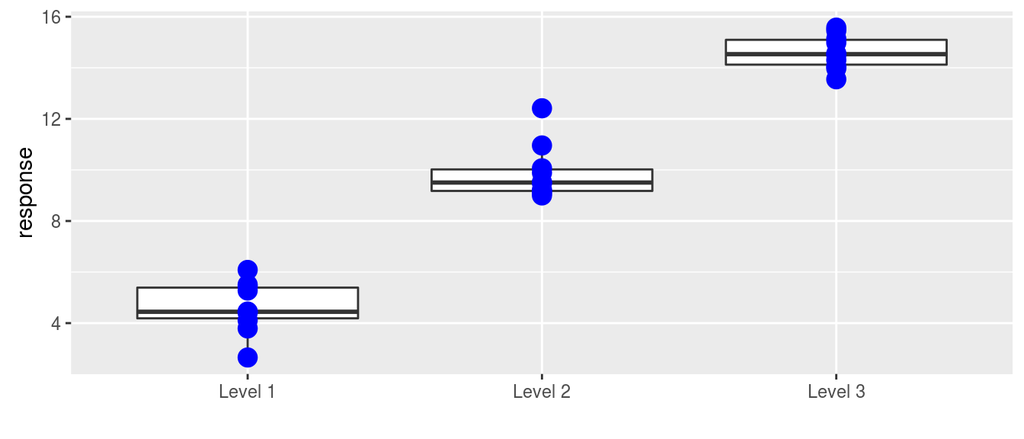

Модель для данного примера имеет такой вид  
\(response = 4.6 + 5.3I_{Level2} + 9.9 I_{Level3}\)

\(I_{i}\) - dummy variable

## Модель для зависимости величины IQ от размера головного мозга

Какая из линий "лучше" описывает облако точек?

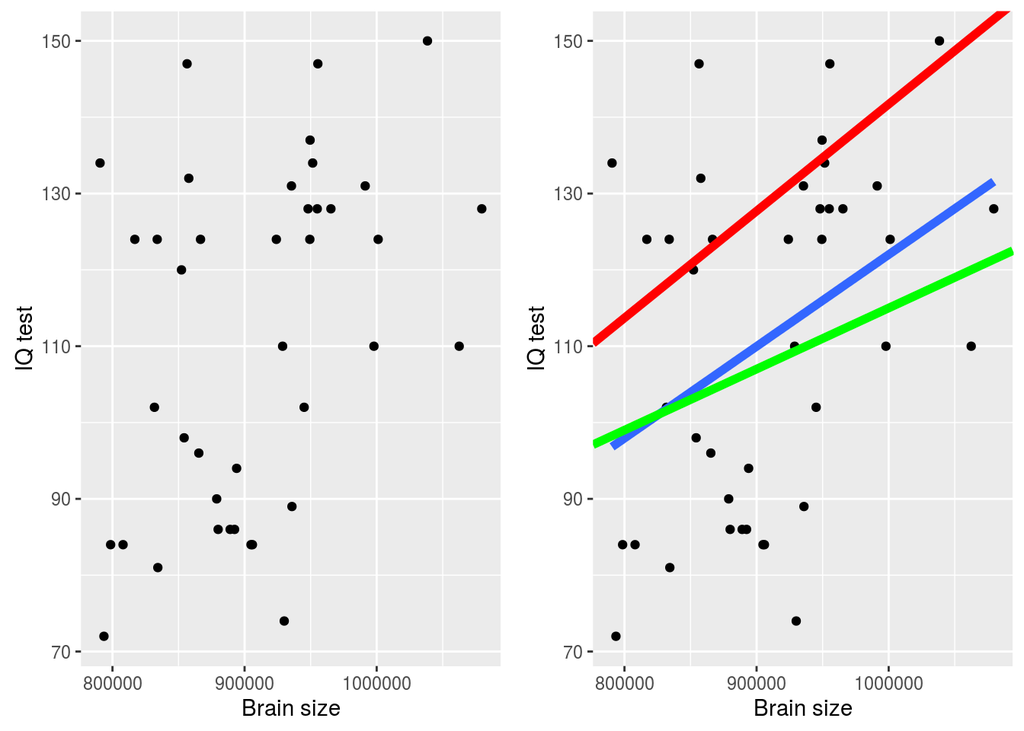

## Найти оптимальную модель позволяет регрессионный анализ

"Essentially, all models are wrong,  
but some are useful"  
(Georg E. P. Box)

## Происхождение термина "регрессия"

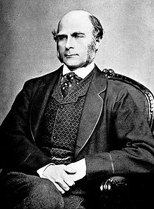

Френсис Галтон (Francis Galton)

"the Stature of the adult offspring … [is] … more mediocre than the stature of their Parents" (цит. по `Legendre & Legendre, 1998`)

Рост *регрессирует* (возвращается) к популяционной средней  
Угловой коэффициент в зависимости роста потомков от роста родителей- *коэффциент регресси*

## Подбор линии регрессии проводится с помощью двух методов

- С помощью метода наименьших квадратов (Ordinary Least Squares) - используется для простых линейных моделей
- Через подбор функции максимального правдоподобия (Maximum Likelihood) - используется для подгонки сложных линейных и нелинейных моделей.

## Кратко о методе макcимального правдоподобия

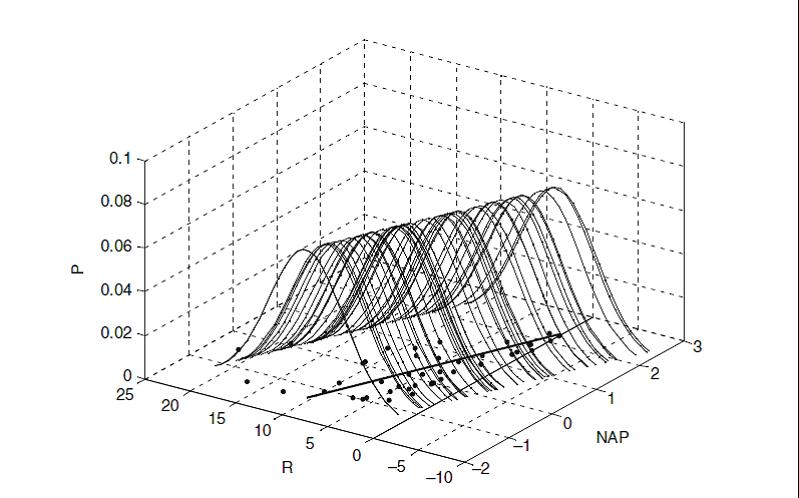

(из кн. Zuur et al., 2009, стр. 19)

## Метод наименьших квадратов

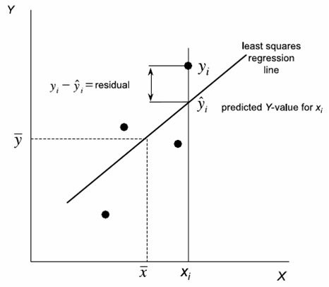

(из кн. Quinn, Keough, 2002, стр. 85)

Остатки (Residuals):  
\[e_i = y_i - \hat{y_i}\]

Линия регрессии (подобраная модель) - это та линия, у которой \(\sum{e_i}^2\) минимальна.

## Подбор модели методом наменьших квадратов с помощью функци `lm()`

`fit <- lm(formula, data)`

Модель записывается в виде формулы

| Mодель | Формула |
| --- | --- |
| Простая линейная регресся \(\hat{y_i}=b_0 + b_1x_i\) | `Y ~ X` `Y ~ 1 + X` `Y ~ X + 1` |
| Простая линейная регрессия (без \(b_0\), "no intercept") \(\hat{y_i}=b_1x_i\) | `Y ~ -1 + X` `Y ~ X - 1` |
| Уменьшенная простая линейная регрессия \(\hat{y_i}=b_0\) | `Y ~ 1` `Y ~ 1 - X` |
| Множественная линейная регрессия \(\hat{y_i}=b_0 + b_1x_i +b_2x_2\) | `Y ~ X1 + X2` |

## Подбор модели методом наменьших квадратов с помощью функци `lm()`

`fit <- lm(formula, data)`

Элементы формул для записи множественных моделей

| Элемент формулы | Значение |
| --- | --- |
| `:` | Взаимодействие предикторов `Y ~ X1 + X2 + X1:X2` |
| `*` | Обзначает полную схему взаимодействий `Y ~ X1 * X2 * X3` аналогично `Y ~ X1 + X2 + X3+ X1:X2 + X1:X3 + X2:X3 + X1:X2:X3` |
| `.` | `Y ~ .` В правой части формулы записываются все переменные из датафрейма, кроме `Y` |

## Подберем модель, наилучшим образом описывающую зависимость результатов IQ-теста от размера головного мозга

```r
brain_model <- lm(PIQ ~ MRINACount, data = brain)
brain_model
```

```
##
## Call:
## lm(formula = PIQ ~ MRINACount, data = brain)
##
## Coefficients:
## (Intercept)   MRINACount
##     1.74376      0.00012
```

## Как трактовать значения параметров регрессионной модели?

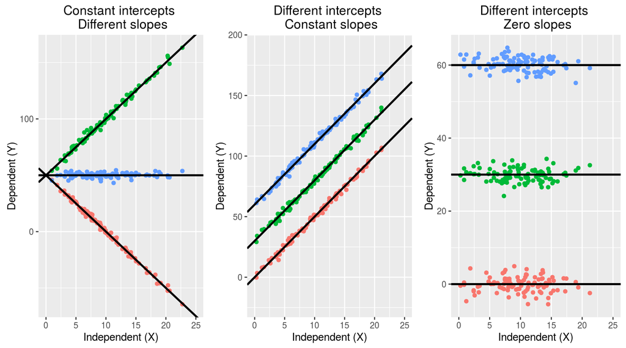

## Как трактовать значения параметров регрессионной модели?

- Угловой коэффициент (*slope*) показывает на сколько *единиц* изменяется предсказанное значение \(\hat{y}\) при изменении на *одну единицу* значения предиктора (\(x\))
- Свободный член (*intercept*) - величина во многих случаях не имеющая "смысла", просто поправочный коэффициент, без которого нельзя вычислить \(\hat{y}\). *NB!* В некоторых линейных моделях он имеет смысл, например, значения \(\hat{y}\) при \(x = 0\).
- Остатки (*residuals*) - характеризуют влияние неучтенных моделью факторов.

## Вопросы:

1. Чему равны угловой коэффициент и свободный член полученной модели `brain_model`?
2. Какое значеие IQ-теста предсказывает модель для человека с объемом мозга равным 900000
3. Чему равно значение остатка от модели для человека с порядковым номером 10?

## Ответы

```r
coefficients(brain_model) [1]
```

```
## (Intercept)
##        1.74
```

```r
coefficients(brain_model) [2]
```

```
## MRINACount
##    0.00012
```

```r
coefficients(brain_model) [1] + coefficients(brain_model) [2] * 900000
```

```
## (Intercept)
##         110
```

```r
brain$PIQ[10] - fitted(brain_model)[10]
```

```
##   10
## 30.4
```

```r
residuals(brain_model)[10]
```

```
##   10
## 30.4
```

## Углубляемся в анализ модели: функция `summary()`

```r
summary(brain_model)
```

```
##
## Call:
## lm(formula = PIQ ~ MRINACount, data = brain)
##
## Residuals:
##    Min     1Q Median     3Q    Max
##  -39.6  -17.9   -1.6   17.0   42.3
##
## Coefficients:
##               Estimate Std. Error t value Pr(>|t|)
## (Intercept)  1.7437570 42.3923825    0.04    0.967
## MRINACount   0.0001203  0.0000465    2.59    0.014 *
## ---
## Signif. codes:  0 '***' 0.001 '**' 0.01 '*' 0.05 '.' 0.1 ' ' 1
##
## Residual standard error: 21 on 38 degrees of freedom
## Multiple R-squared:  0.15,   Adjusted R-squared:  0.127
## F-statistic: 6.69 on 1 and 38 DF,  p-value: 0.0137
```

## Что означают следующие величины?

`Estimate`  
`Std. Error`  
`t value`  
`Pr(>|t|)`

## Оценки параметров регрессионной модели

| Параметр | Оценка | Стандартная ошибка |
| --- | --- | --- |
| \(\beta_1\) Slope | \(b _1 = \frac {\sum _{i=1}^{n} {[(x _i - \bar {x})(y _i - \bar {y})]}}{\sum _{i=1}^{n} {(x _i - \bar x)^2}}\) или проще \(b_0 = r\frac{sd_y}{sd_x}\) | \(SE _{b _1} = \sqrt{\frac{MS _e}{\sum _{i=1}^{n} {(x _i - \bar {x})^2}}}\) |
| \(\beta_0\) Intercept | \(b_0 = \bar y - b_1 \bar{x}\) | \(SE _{b _0} = \sqrt{MS _e [\frac{1}{n} + \frac{\bar x}{\sum _{i=1}^{n} {(x _i - \bar x)^2}}]}\) |
| \(\epsilon _i\) | \(e_i = y_i - \hat {y_i}\) | \(\approx \sqrt{MS_e}\) |

## Для чего нужны стандартные ошибки?

- Они нужны, поскольку мы *оцениваем* параметры по *выборке*
- Они позволяют построить доверительные интервалы для параметров
- Их используют в статистических тестах

## Графическое представление результатов

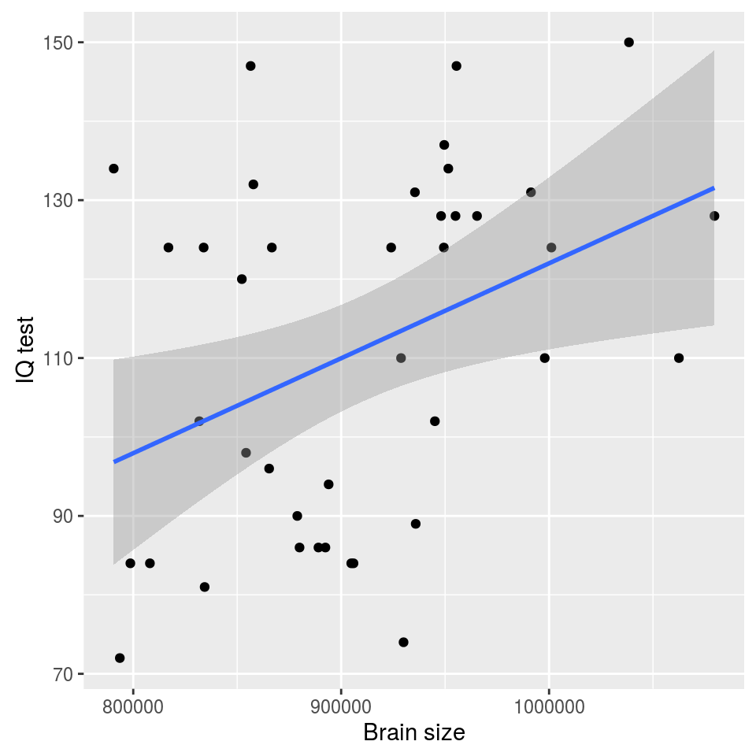

```r
pl_brain + geom_smooth(method="lm")
```

Доверительная зона регрессии. В ней с 95% вероятностью лежит регрессионная прямая, описывающая связь в генеральной совокупности.  
Возникает из-за неопределенности оценок коэффициентов регрессии, вследствие выборочного характера оценок.

## Симулированный пример

Линии регресси, полученные для 100 выборок (по 20 объектов в каждой), взятых из одной и той же генеральной совокупности

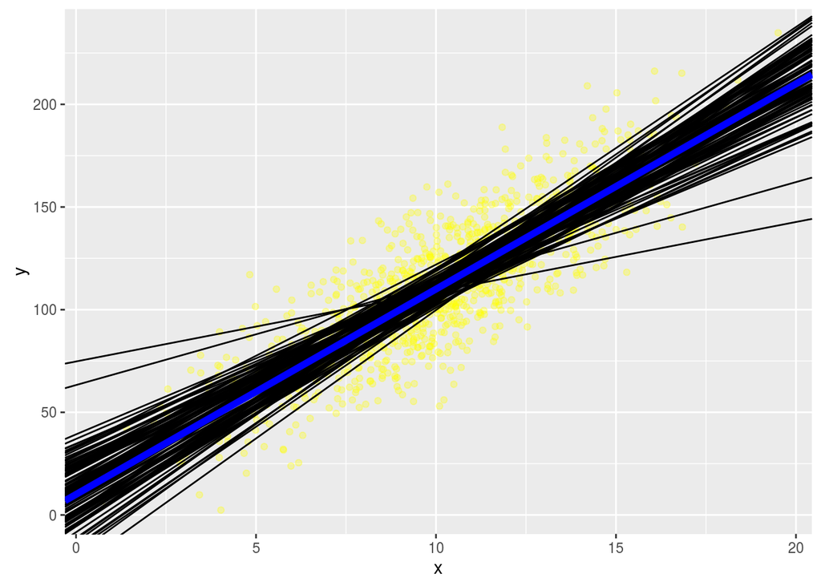

## Доверительные интервалы для коэффициентов уравнения регрессии

```r
coef(brain_model)
```

```
## (Intercept)  MRINACount
##     1.74376     0.00012
```

```r
confint(brain_model)
```

```
##                   2.5 %    97.5 %
## (Intercept) -84.0751348 87.562649
## MRINACount    0.0000261  0.000214
```

## Для разных \(\alpha\) можно построить разные доверительные интервалы

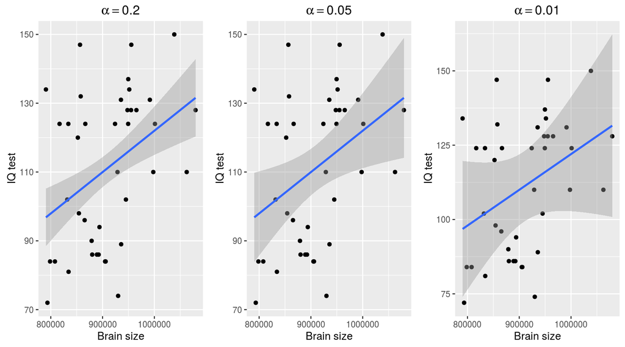

## Важно!

Если коэффициенты уравнения регресси - лишь приблизительные оценки параметров, то предсказать значения зависимой переменной можно только *с нeкоторой вероятностью*.

## Какое значение IQ можно ожидать у человека с размером головного мозга 900000?

```r
newdata <- data.frame(MRINACount = 900000)

predict(brain_model, newdata, interval = "prediction", level = 0.95, se = TRUE)$fit
```

```
##   fit  lwr upr
## 1 110 66.9 153
```

- При размере мозга 900000 среднее значение IQ будет, с вероятностью 95%, находиться в интервале от 67 до 153.

## Отражаем на графике область значений, в которую попадут 95% предсказанных величин IQ

Подготавливаем данные

```r
brain_predicted <- predict(brain_model, interval="prediction")
brain_predicted <- data.frame(brain, brain_predicted)
head(brain_predicted)
```

```
##   Gender FSIQ VIQ PIQ Weight Height MRINACount fit  lwr upr
## 1 Female  133 132 124    118   64.5     816932 100 56.1 144
## 2   Male  140 150 124     NA   72.5    1001121 122 78.2 166
## 3   Male  139 123 150    143   73.3    1038437 127 81.9 171
## 4   Male  133 129 128    172   68.8     965353 118 74.5 161
## 5 Female  137 132 134    147   65.0     951545 116 73.0 159
## 6 Female   99  90 110    146   69.0     928799 113 70.4 157
```

## Отражаем на графике область значений, в которую попадут 95% предсказанных величин IQ

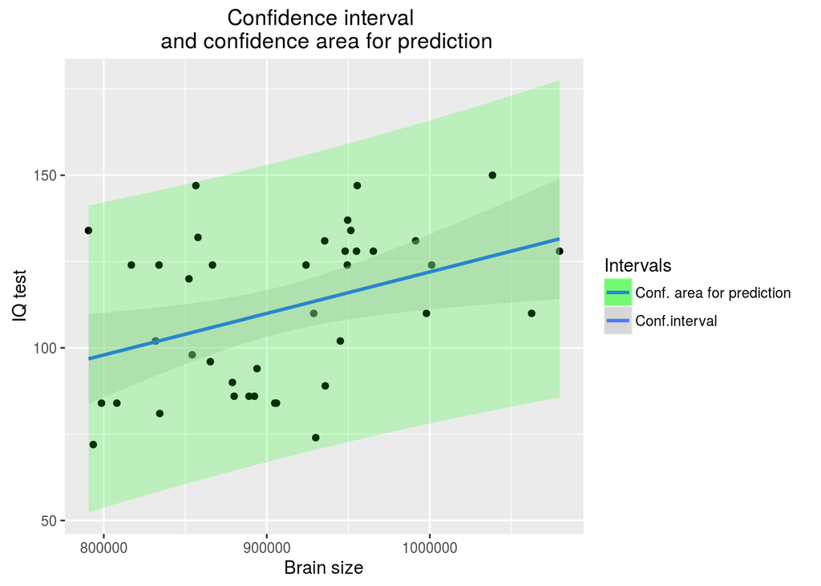

## Код для этого графика

Ранее вы уже создали график

```r
pl_brain <- ggplot(brain, aes(x = MRINACount, y = PIQ)) + geom_point() +
    xlab("Brain size") + ylab("IQ test")
```

Теперь его можно дополнить так:

```r
pl_brain +
# 1) Линия регрессии и ее дов. интервал Если мы указываем fill внутри
# aes() и задаем фиксированное значение - появится соотв. легенда с
# названием.  alpha - задает прозрачность
geom_smooth(method = "lm", aes(fill = "Conf.interval"), alpha = 0.4) +
    # 2) Интервал предсказаний создаем при помощи геома ribbon ('лента')
# Данные берем из другого датафрейма - из brain_predicted ymin и ymax -
# эстетики геома ribbon, которые задают нижний и верхний край ленты в
# точках с заданным x (x = MRINACount было задано в ggplot() при
# создании pl_brain, поэтому сейчас его указывать не обязательно)
geom_ribbon(data = brain_predicted, aes(ymin = lwr, ymax = upr, fill = "Conf. area for prediction"),
    alpha = 0.2) +
# 3) Вручную настраиваем цвета заливки при помощи шкалы fill_manual.
# Ее аргумент name - название соотв. легенды, values - вектор цветов
scale_fill_manual(name = "Intervals", values = c("green", "gray")) +
# 4) Название графика
ggtitle("Confidence interval \n and confidence area for prediction")
```

## Важно!

*Модель "работает" только в том диапазоне значений независимой переменной (\(x\)), для которой она построена (интерполяция). Экстраполяцию надо применять с большой осторожностью.*

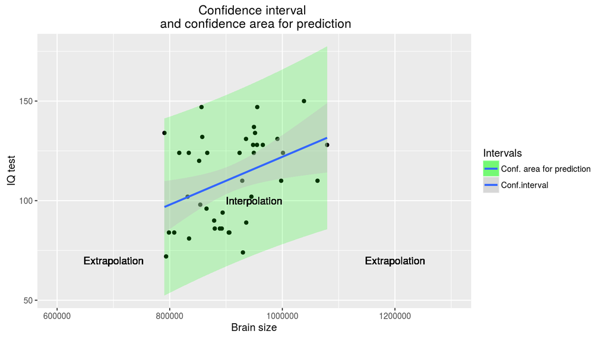

## Итак, что означают следующие величины?

- `Estimate`
- Оценки праметров регрессионной модели
- `Std. Error`
- Стандартная ошибка для оценок
- Осталось решить, что такое `t value`, `Pr(>|t|)`

## Тестирование гипотез с помощью линейных моделей

### Два равноправных способа

- Проверка достоверности оценок коэффициента \(b_1\) (t-критерий).
- Оценка соотношения описанной и остаточной дисперсии (F-критерий).

## Тестирование гипотез с помощью t-критерия

Зависимость есть, если \(\beta_1 \ne 0\)

Нулевая гипотеза \(H_0: \beta = 0\)

Тестируем гипотезу

\[t=\frac{b_1-0}{SE_{b_1}}\]

Число степеней свободы: \(df=n-2\)  
>- Итак,  
>- `t value` - Значение t-критерия  
>- `Pr(>|t|)` - Уровень значимости

## Зависит ли IQ от размера головного мозга?

\(PIQ = 1.744 + 0.0001202 MRINACount\)

```r
summary(brain_model)
```

```
##
## Call:
## lm(formula = PIQ ~ MRINACount, data = brain)
##
## Residuals:
##    Min     1Q Median     3Q    Max
##  -39.6  -17.9   -1.6   17.0   42.3
##
## Coefficients:
##               Estimate Std. Error t value Pr(>|t|)
## (Intercept)  1.7437570 42.3923825    0.04    0.967
## MRINACount   0.0001203  0.0000465    2.59    0.014 *
## ---
## Signif. codes:  0 '***' 0.001 '**' 0.01 '*' 0.05 '.' 0.1 ' ' 1
##
## Residual standard error: 21 on 38 degrees of freedom
## Multiple R-squared:  0.15,   Adjusted R-squared:  0.127
## F-statistic: 6.69 on 1 and 38 DF,  p-value: 0.0137
```

## Тестирование гипотез с помощью F-критерия

*Объясненная дисперсия зависимой перменной*  
\(SS_{Regression}=\sum{(\hat{y}-\bar{y})^2}\)  
\(df_{Regression} = 1\)  
\(MS_{Regression} =\frac{SS_{Regression}}{df}\)  
*Остаточная дисперсия завсимой переменной*  
\(SS_{Residual}=\sum{(\hat{y}-y_i)^2}\)  
\(df_{Residual} = n-2\)  
\(MS_{Residual} =\frac{SS_{Residual}}{df_{Residual}}\)  
*Полная дисперсия зависимой переменной*  
\(SS_{Total}=\sum{(\bar{y}-y_i)^2}\)  
\(df_{Total} = n-1\)  
\(MS_{Total} =\frac{SS_{Total}}{df_{Total}}\)

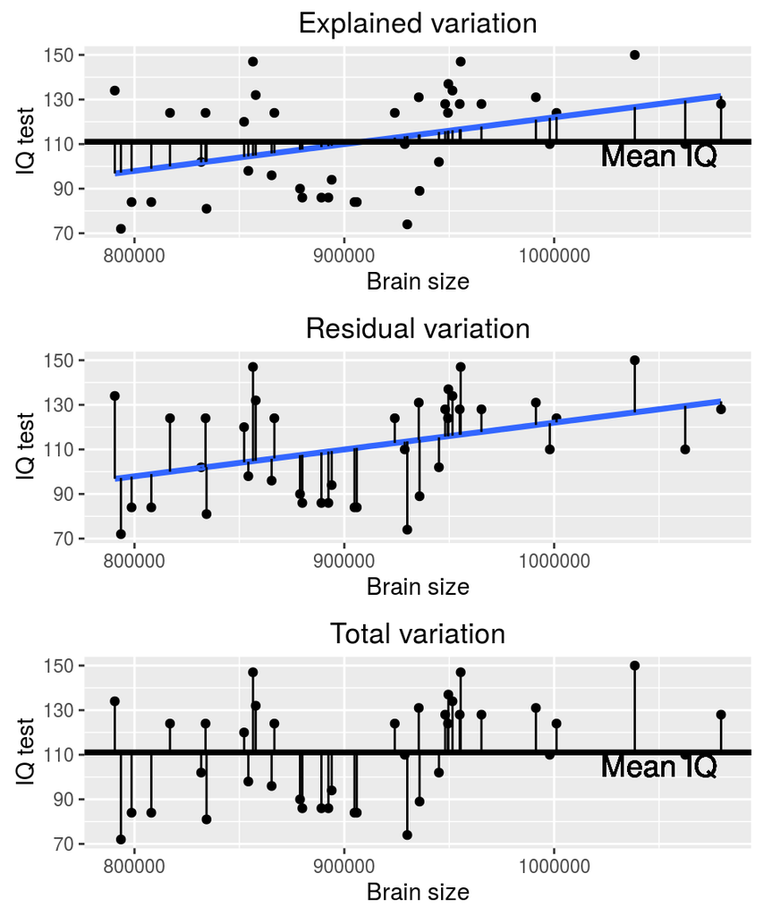

## F критерий

Если зависимости нет, то  
\(MS _{Regression} = MS_{Residual}\)

\[ F= \frac{MS _{Regression}}{MS_{Residual}}\]

Логика та же, что и с t-критерием

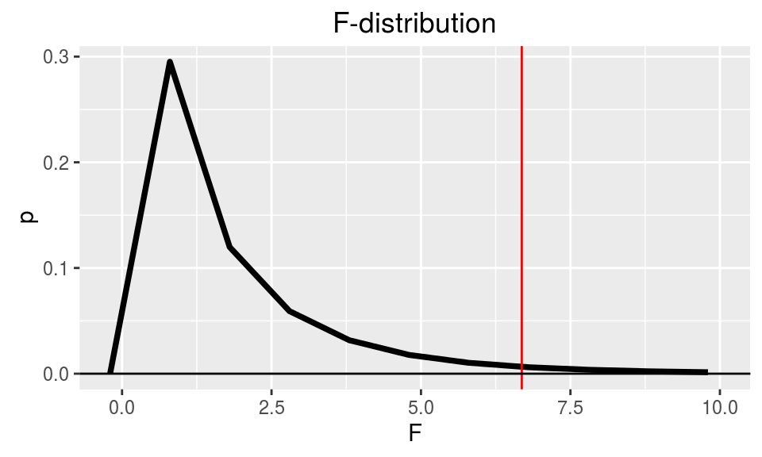

Форма F-распределения зависит от двух параметров \(df_{Regression} = 1\) и \(df_{Residual} = n-2\)

## Оценка качества подгонки модели с помощью коэффициента детерминации

### В чем различие между этми двумя моделями?

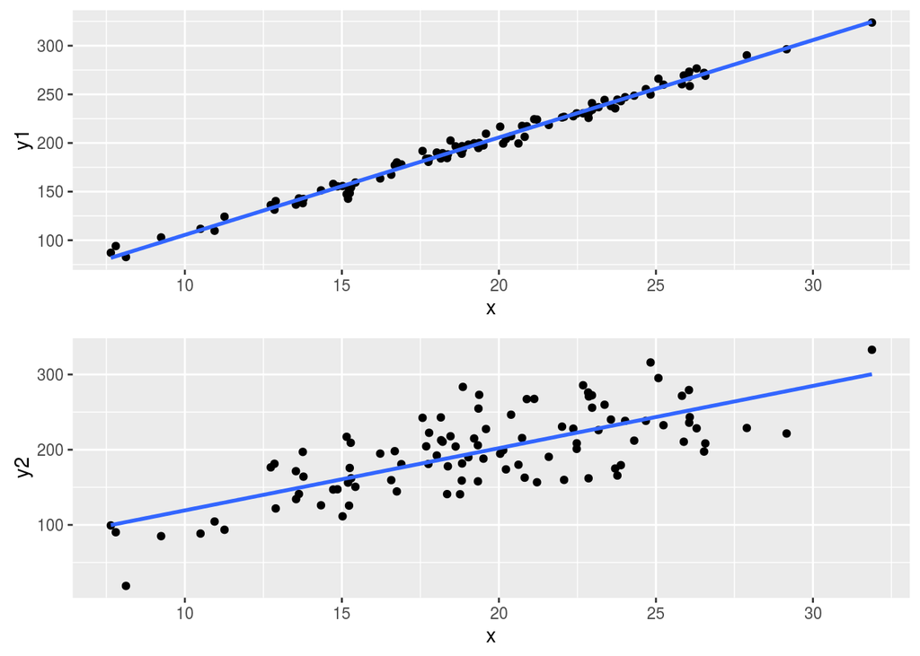

## Оценка качества подгонки модели с помощью коэффициента детерминации

Коэффициент детерминации описывает какую долю дисперсии зависимой переменной объясняет модель

- \[R^2 = \frac{SS_{Regression}}{SS_{Total}}\]
- \[0< R^2 < 1\]
- \[R^2 = r^2\]

## Еще раз смотрим на результаты регрессионного анализа зависимости IQ от размеров мозга

```r
summary(brain_model)
```

```
##
## Call:
## lm(formula = PIQ ~ MRINACount, data = brain)
##
## Residuals:
##    Min     1Q Median     3Q    Max
##  -39.6  -17.9   -1.6   17.0   42.3
##
## Coefficients:
##               Estimate Std. Error t value Pr(>|t|)
## (Intercept)  1.7437570 42.3923825    0.04    0.967
## MRINACount   0.0001203  0.0000465    2.59    0.014 *
## ---
## Signif. codes:  0 '***' 0.001 '**' 0.01 '*' 0.05 '.' 0.1 ' ' 1
##
## Residual standard error: 21 on 38 degrees of freedom
## Multiple R-squared:  0.15,   Adjusted R-squared:  0.127
## F-statistic: 6.69 on 1 and 38 DF,  p-value: 0.0137
```

## Adjusted R-squared - скорректированный коэффициет детерминации

Применяется если необходимо сравнить две модели с разным количеством параметров

\[ R^2_{adj} = 1- (1-R^2)\frac{n-1}{n-k}\]

\(k\) - количество параметров в модели

Вводится штраф за каждый новый параметр

## Как записываются результаты регрессионного анлиза в тексте статьи?

Мы показали, что связь между результатами теста на IQ описывается моделью вида  
IQ = 1.74 + 0.00012 MRINACount (\(F_{1,38}\) = 6.686, p = 0.0136, \(R^2\) = 0.149)

## Summary

- Модель простой линейной регрессии \(y _i = \beta _0 + \beta _1 x _i + \epsilon _i\)
- Параметры модели оцениваются на основе выборки
- В оценке коэффициентов регрессии и предсказанных значений существует неопределенность: необходимо вычислять доверительный интервал.
- Доверительные интервалы можно расчитать, зная стандартные ошибки.
- Гипотезы о наличии зависимости можно тестировать при помощи t- или F-теста. \((H _0: \beta _1 = 0\))
- Качество подгонки модели можно оценить при помощи коэффициента детерминации \((R^2)\)

## Что почитать

- Гланц, 1999, стр. 221-244
- [Open Intro to Statistics](https://docs.google.com/viewer?docex=1&url=http://www.openintro.org/stat/down/OpenIntroStatSecond.pdf): [Chapter 7. Introduction to linear regression](https://docs.google.com/viewer?docex=1&url=http://www.openintro.org/stat/down/oiStat2_07.pdf), pp. 315-353.
- Quinn, Keough, 2002, pp. 78-110